# stommel_fdm

### Full form of the governing equation

\begin{align*} \frac{\partial \mathbf{u}}{\partial t} + \mathbf{u} \cdot \nabla \mathbf{u} + 2\Omega \times \mathbf{u}&= -\frac{1}{\rho} \nabla p + \frac{1}{\rho} \frac{ \partial \boldsymbol{\tau} }{\partial z} + \mathbf{g} + \mathbf{F}\\ \nabla \cdot \mathbf{u} &= 0 \end{align*}

- $\frac{\partial \mathbf{u}}{\partial t}$ is the (local) acceleration term.
- $\mathbf{u} \cdot \nabla \mathbf{u}$ is the inertial / advection term
- $2\Omega \times \mathbf{u}$ is the Coriolis force
- $-\frac{1}{\rho} \nabla p$ is pressure gradient force.
- $\frac{1}{\rho} \frac{ \partial \boldsymbol{\tau} }{\partial z}$ is some shear stress
- $\mathbf{g}$ is gravity
- $\nabla \cdot \mathbf{u} = 0$ means the flow is incompressible.

### Stommel model for western boundary current (WBC)

Assumptions and simplification:

- The flow is in steady state $\left(\frac{\partial \mathbf{u}}{\partial t} = 0 \right)$
- The flow is averaged over a long period of time ($\mathbf{u} \cdot \nabla \mathbf{u} = 0$).
- $\beta$-plane approximation; $f = f_0 + \beta y$, where $\beta = \frac{\partial f}{\partial y}$
- There is no vertical velocity. ($w=0$)
- The ocean depth $d$ is fixed.

Therefore the set of equations: \begin{align*} \begin{cases} \large-fv = - \frac{1}{\rho} \frac{\partial p}{\partial x} + \frac{1}{\rho} \frac{\partial \tau_x}{\partial z} \\ \large fu = - \frac{1}{\rho} \frac{\partial p}{\partial y} + \frac{1}{\rho} \frac{\partial \tau_y}{\partial z}\\ \large \frac{\partial u}{\partial x} + \frac{\partial v}{\partial y} = 0 \end{cases} \end{align*}

Note that $\mathbf{u} \equiv \mathbf{u}(x,y,z) = \left( u,v,0 \right)^T$, $p \equiv p(x,y,z)$ and for $\mathbf{\tau}$ \begin{align*} \text{In x-direction: }\,\,\,\,\, \tau_x\biggr|_{z=0} &= \rho \tau_0 \sin{\left( \pi \left( \frac{a y}{L_y} - \frac{1}{2} \right) \right)} && \tau_x\biggr|_{z=-d} = r \rho U \\ \text{In y-direction: }\,\,\,\,\, \tau_y\biggr|_{z=0} &= 0 && \tau_y\biggr|_{z=-d} = r \rho V \\ \end{align*} $L_y$ is the length of the domain in y-direction and $a$ relates to the frequency of the wind stress. If $a = 1$, then it is single gyres system. If $a=2$ then it is double gyres system. $U$ and $V$ are defined below.

For shear stress, at ocean surface ($z=0$), the domain is only affect by x-direction wind stress; at ocean bottom ($z=-d$), there is bottom drag / friction that is linearly proportional to velocity. (The -ve sign will appear later)

#### Solving the system of equations

Cross differentiation of first two equation to eliminate pressure term:

\begin{align*} -\frac{\partial f}{\partial y}v - f \frac{\partial v}{\partial y} &= - \frac{1}{\rho} \frac{\partial^2 p}{\partial y \partial x} + \frac{1}{\rho} \frac{\partial}{\partial y} \frac{\partial \tau_x}{\partial z} \\ f \frac{\partial u}{\partial x} &= - \frac{1}{\rho} \frac{\partial^2 p}{\partial x \partial y} + \frac{1}{\rho} \frac{\partial}{\partial x} \frac{\partial \tau_y}{\partial z}\\ \end{align*}

First equation minus second equation (or other way around):

\begin{align*} -\frac{\partial f}{\partial y}v - f \frac{\partial v}{\partial y} - f \frac{\partial u}{\partial x} &= \frac{1}{\rho} \frac{\partial}{\partial y} \frac{\partial \tau_x}{\partial z} - \frac{1}{\rho} \frac{\partial}{\partial x} \frac{\partial \tau_y}{\partial z}\\ \beta v + f \left(\frac{\partial u}{\partial x} + \frac{\partial v}{\partial y} \right) &= -\frac{1}{\rho} \frac{\partial}{\partial y} \frac{\partial \tau_x}{\partial z} + \frac{1}{\rho} \frac{\partial}{\partial x} \frac{\partial \tau_y}{\partial z} \\ \end{align*}

Let the depth-integrated velocity be $U$ and $V$, where \begin{align*} U &= \int_{-d}^{0} u \, dz\\ V &= \int_{-d}^{0} v \, dz \end{align*}

Assuming the integral can "punch" through the derivatives. The depth-integrated momentum equation:

\begin{align*} \Longrightarrow \beta V + f \left( \frac{\partial U}{\partial x} + \frac{\partial V}{\partial y} \right) &= - \frac{1}{\rho} \frac{\partial}{\partial y} \left(\tau_x \biggr|_{z=0} - \tau_x \biggr|_{z=-d} \right) + \frac{1}{\rho} \frac{\partial}{\partial x} \left(\tau_y \biggr|_{z=0} - \tau_y \biggr|_{z=-d} \right) \\ &= - \frac{\partial}{\partial y} \left( \tau_0 \sin{\left( \pi \left( \frac{a y}{L_y} - \frac{1}{2} \right) \right)} \right) + r\frac{\partial U}{\partial y} - r\frac{\partial V}{\partial x} \\ \end{align*}

Depth-integrated continuity equation:

\begin{align*} \frac{\partial U}{\partial x} + \frac{\partial V}{\partial y} &= 0 \\ \end{align*}

#### Streamfunction $\Psi(x,y)$

\begin{align*} \frac{\partial \Psi}{\partial x} &= V \\ \frac{\partial \Psi}{\partial y} &= -U\\ \therefore \left( U,V \right)^T &= \left(-\frac{\partial \Psi}{\partial y}, \frac{\partial \Psi}{\partial x} \right)^T \end{align*}

Note that continuity is automatically satisfied: $$ \frac{\partial}{\partial x} \frac{\partial \Psi}{\partial y} - \frac{\partial}{\partial y} \frac{\partial \Psi}{\partial x} = 0 $$

Therefore, only need to consider depth-integrated momentum equation, after substitution of streamfunction and some computation: \begin{align*} \beta \frac{\partial \Psi}{\partial x} + r \nabla^2 \Psi &= - \frac{ a \pi \tau_0}{L_y} \cos{\left( \pi \left( \frac{a y}{L_y} - \frac{1}{2} \right) \right)} \\ \iff \,\,\,\,\,\beta \frac{\partial \Psi}{\partial x} + r \left( \frac{\partial^2 \Psi}{{\partial x}^2} + \frac{\partial^2 \Psi}{{\partial y}^2} \right) &= - \frac{ a \pi \tau_0}{L_y} \cos{\left( \pi \left( \frac{a y}{L_y} - \frac{1}{2} \right) \right)}\\ &= \Sigma(y) \end{align*}

Hence, by streamfunction substitution, only need to solve one equation, but is an order higher to the original equation.

#### Boundary conditions

Dirichlet conditions at boundary:

\begin{align*} \Psi(0,y)= \Psi(L_x,y) = \Psi(x,0) = \Psi(x,L_y) = 0 \end{align*}

With the above Dirichlet boundary conditions, the PDE should be well-contrained already.

Additionally, Neumann condition can also be applied at boundary (no flux out of boundary) (if ever needed):

\begin{align*} \nabla \Psi \cdot \mathbf{n} = 0 \end{align*}

where $\mathbf{n}$ is the unit normal vector for the boundaries.

### Finite difference

Here the index $i,j$ indicate the $x,y$ positioning of grid points.

Forward difference for $f_x(x,y)$ (Similarily for $f_y$): \begin{align*} \frac{\partial f_{i,j}}{\partial x} \approx \frac{f_{i+1,j} - f_{i,j}}{\Delta x}\,\,\,\,\,,\,\,\,\,\,\,\,\, \frac{\partial f_{i,j}}{\partial y} \approx \frac{f_{i,j+1} - f_{i,j}}{\Delta y} \end{align*}

Central difference for $f_x(x,y)$ (Similarily for $f_y$): \begin{align*} \frac{\partial f_{i,j}}{\partial x} \approx \frac{f_{i+1,j} - f_{i-1,j}}{2\Delta x}\,\,\,\,\,,\,\,\,\,\,\,\,\, \frac{\partial f_{i,j}}{\partial y} \approx \frac{f_{i,j+1} - f_{i,j-1}}{2\Delta y} \end{align*}

Second order central difference for $f_{xx}(x,y)$ (Similarily for $f_{yy}(x,y)$)

\begin{align*} \frac{\partial^2 f_{i,j}}{{\partial x}^2} \approx \frac{f_{i+1,j} -2f_{i,j} + f_{i-1,j}}{{\Delta x}^2} \,\,\,\,\,,\,\,\,\,\,\,\,\, \frac{\partial^2 f_{i,j}}{{\partial x}^2} \approx \frac{f_{i,j+1} -2f_{i,j} + f_{i,j-1}}{{\Delta y}^2} \end{align*}

#### Discretisation

Take $\Delta x = \Delta y$ and use forward difference.

\begin{align*} \frac{\beta}{\Delta x} \left(\Psi_{i+1,j} - \Psi_{i,j} \right) + \frac{r}{{\Delta x}^2} \left( \Psi_{i+1,j} - 2\Psi_{i,j} + \Psi_{i-1,j} + \Psi_{i,j+1} - 2\Psi_{i,j} + \Psi_{i,j-1} \right) = \Sigma (y) \\ \Longrightarrow -\left( \frac{\beta}{\Delta x} + \frac{4r}{{\Delta x}^2} \right) \Psi_{i,j} = \Sigma (y) - \frac{\beta}{\Delta x} \Psi_{i+1,j} - \frac{r}{{\Delta x}^2} \left( \Psi_{i+1,j} + \Psi_{i-1,j} + \Psi_{i,j+1} + \Psi_{i,j-1} \right) \end{align*}

Put $B = \beta / \Delta x$ and $R = r / {\Delta x}^2$. Re-arranging becomes:

\begin{align*} \Longrightarrow \Psi_{i,j} &= \frac{1}{B+4R} \left( \, -\Sigma (y) + B \Psi_{i+1,j} + R \left( \Psi_{i+1,j} + \Psi_{i-1,j} + \Psi_{i,j+1} + \Psi_{i,j-1} \right) \, \right) \\ &= \frac{1}{B+4R} \left( \, \frac{ a \pi \tau_0}{L_y} \cos{\left( \pi \left( \frac{a y_{i,j}}{L_y} - \frac{1}{2} \right) \right)} + B \Psi_{i+1,j} + R \left( \Psi_{i+1,j} + \Psi_{i-1,j} + \Psi_{i,j+1} + \Psi_{i,j-1} \right) \, \right) \end{align*}

This can then be solved using iteration. Below used Jacobi method.

Alternatively central differencing for $\frac{\partial \Psi}{\partial x}$, which is a faster converging method, can be used:

\begin{align*} \frac{\partial \Psi_{i,j}}{\partial x} \approx \frac{\Psi_{i+1,j} - \Psi_{i-1,j}}{2\Delta x} \end{align*}

#### Wrapping things into function

```python
import numpy as np
import matplotlib.pyplot as plt
```

```python
def solve_stommel_fdm(
        Lx=1.0,         # domain Lx by Ly
        Ly=1.0,
        nx=51,          # number of grid point x,y axis
        ny=None,
        r=0.2,          # linear friction coeff
        beta=1.0,       # coriolis parameter
        a=1,            # contol number of gyres, preferably integer
        tau0=0.001,     # magnitude of wind stress
        tol=1e-10,       # tolerance
        maxiter=70000,  # max no of iteration
        verbose=False,
        coord_out=True, # output X,Y for plotting
        central_diff=True, # enable central 2nd order diff
        Neumann=False
):
    assert isinstance(nx, int)
    if ny is None:
        # make sure dx = dy
        ny = round((nx - 1) * Ly/Lx) + 1
    else:
        # user input
        assert isinstance(ny, int)
        assert ny == (nx - 1) * Ly/Lx + 1

    # dx = dy
    dx = Lx/(nx - 1)
    R = r / (dx*dx)
    B = beta / dx

    x = np.linspace(0.0, Lx, nx)
    y = np.linspace(0.0, Ly, ny)
    X, Y = np.meshgrid(x, y, indexing='ij')
    Sigma = -a*np.pi*tau0/Ly * np.cos(np.pi* (a/Ly * Y[1:-1, 1:-1] - 0.5))    # every iteration is the same

    # forward differencing
    counter = 0
    diff = 10

    # start with all 0
    # Dont touch the boundary nodes
    psi_new = np.zeros((nx,ny))
    psi = np.zeros((nx,ny))

    # try forward

    while diff > tol:
        # compute new psi
        if central_diff is True:
            psi_new[1:-1, 1:-1] = - 1/(4*R) * Sigma + 0.5/(4*R) * B * (psi[2:, 1:-1] - psi[:-2, 1:-1]) + 0.25*(psi[2:, 1:-1] + psi[:-2, 1:-1] + psi[1:-1, 2:] + psi[1:-1, :-2])
        else:
            psi_new[1:-1, 1:-1] = 1/(B+4*R) * ( - Sigma + B * psi[2:, 1:-1] + R * (psi[2:, 1:-1] + psi[:-2, 1:-1] + psi[1:-1, 2:] + psi[1:-1, :-2]) )

        if Neumann:
            # if ever needed
            # enforce Neumann boundary condition every iteration psi boundary has dirichlet bc where they all =0
            psi_new[1,:] = psi_new[0,:]    # psi'(0,y) = 0
            psi_new[-2,:] = psi_new[-1,:]  # psi'(Lx,y) = 0
            psi_new[:,1] = psi_new[:,0]    # psi'(x,0) = 0
            psi_new[:,-2] = psi_new[:,-1]  # psi'(x,Ly) = 0

        # compute diff using 2-norm
        # scale the norm by sqrt(nx*ny)
        diff = np.linalg.norm(psi_new - psi)/np.sqrt(nx*ny)

        if diff < tol:
            print(f"Convergence reached after {counter} iteration; L2 error {diff}")
            break

        # update
        np.copyto(psi, psi_new)
        # psi = psi_new

        if (counter % 100 == 0) and (verbose):
            print(f"{counter} iteration: L2 error is {diff}")

        if counter == maxiter:
            print(f"Max iteration reached. error = {diff}")
            break

        counter += 1

    if coord_out:
        return psi_new, X, Y
    else:
        return psi_new
```

```python
psi_out, X, Y = solve_stommel_fdm()
```

```
Convergence reached after 3666 iteration; L2 error 9.977642474556766e-11
```

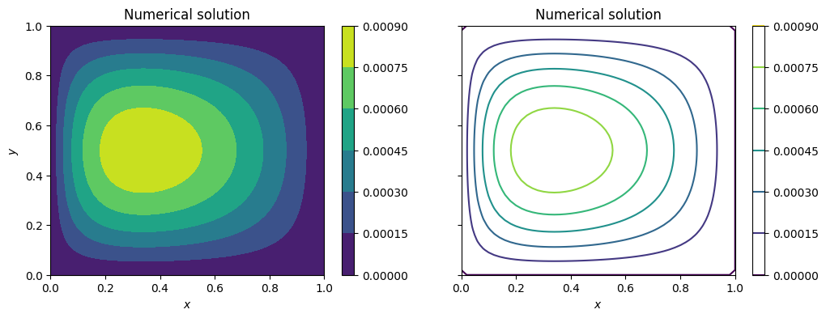

```python
fig, ax = plt.subplots(1,2, sharey=True, figsize=(12,4))

cmf = ax[0].contourf(X, Y, psi_out, 5)
cm = ax[1].contour(X, Y, psi_out, 5)

ax[0].set_xlabel(r'$x$')
ax[0].set_ylabel(r'$y$')
ax[0].set_title('Numerical solution')
fig.colorbar(cmf)

ax[1].set_xlabel(r'$x$')
ax[1].set_title('Numerical solution')
fig.colorbar(cm)
```

#### Exact solution

$$ \Psi(x,y)=\frac{\tau_0 L_y}{ar\pi} \left\{ 1- \frac{(1-e^{C_3 L_x}) e^{C_2 x} - (1-e^{C_2 L_x}) e^{C_3 x} }{e^{C_2 L_x} - e^{C_3 L_x}} \right\} \cos{\left( \pi\left( \frac{ay}{L_y} - \frac{1}{2} \right) \right)} $$

where,

\begin{align} C_2 &= -\frac{\beta}{2r} + \sqrt{\left( \frac{\beta}{2r} \right)^2 + \left( \frac{a \pi}{L_y} \right)^2}\\ C_3 &= -\frac{\beta}{2r} - \sqrt{\left( \frac{\beta}{2r} \right)^2 + \left( \frac{a \pi}{L_y} \right)^2 } \end{align}

```python
# exact solution

def psi_exact(
    x,
    y,
    Lx=1.0,         # domain Lx by Ly
    Ly=1.0,
    r=0.2,          # linear friction coeff
    beta=1.0,       # coriolis parameter
    a=1,            # contol number of gyres, preferably integer
    tau0=0.001):     # magnitude of wind stress

    C2 = -beta / 2 / r + np.sqrt( (beta / 2 / r)**2 + (a*np.pi/Ly)**2 )
    C3 = -beta / 2 / r - np.sqrt( (beta / 2 / r)**2 + (a*np.pi/Ly)**2 )
    A = tau0 * Ly / a / r / np.pi
    nom = (1 - np.exp(C3 * Lx)) * np.exp(C2 * x) - (1 - np.exp(C2 * Lx)) * np.exp(C3 * x)
    denom = np.exp(C2*Lx) - np.exp(C3*Lx)
    wind_harm = np.cos(np.pi*(a*y/Ly - 0.5))

    return A*(1-nom/denom)*wind_harm
```

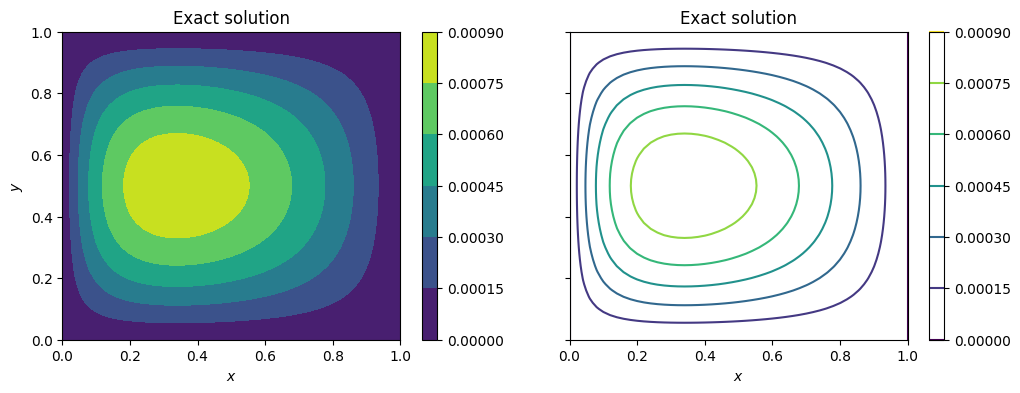

```python
# plot exact solution

psi_e = psi_exact(X,Y)
fig, ax = plt.subplots(1,2, sharey=True, figsize=(12,4))

cmf = ax[0].contourf(X, Y, psi_e, 5)
cm = ax[1].contour(X, Y, psi_e, 5)

ax[0].set_xlabel(r'$x$')
ax[0].set_ylabel(r'$y$')
ax[0].set_title('Exact solution')
fig.colorbar(cmf)

ax[1].set_xlabel(r'$x$')
ax[1].set_title('Exact solution')
fig.colorbar(cm)
```

```python
# error
nx = 51
ny = round((nx - 1)) + 1
print("L2 Error between exact and numerical solution: ", np.linalg.norm(psi_e-psi_out)/np.sqrt(nx*ny))
```

```
L2 Error between exact and numerical solution:  9.634620139750508e-08
```

```python
# aspect ratio 1 : 4
Lx = 4.0
Ly = 1.0
nx = 201
r = 0.1
psi_out, X, Y = solve_stommel_fdm(Lx=Lx, Ly=Ly, nx=nx, r=0.1)
```

```
Convergence reached after 5468 iteration; L2 error 9.990741178660287e-11
```

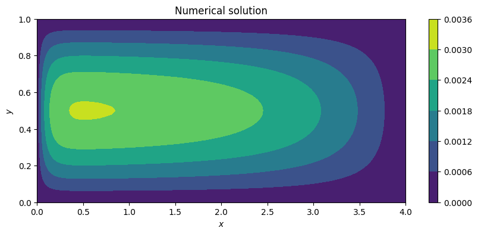

```python
fig, ax = plt.subplots(figsize=(10,4))

cmf = ax.contourf(X, Y, psi_out, 5)

ax.set_xlabel(r'$x$')
ax.set_ylabel(r'$y$')
ax.set_title('Numerical solution')
fig.colorbar(cmf)
```

```python
# aspect ratio 1:2 and a = 2
Lx = 2.0
Ly = 1.0
nx = 101
r = 0.1
a = 2
psi_out, X, Y = solve_stommel_fdm(Lx=Lx, Ly=Ly, nx=nx, r=r, a=a)
```

```
Convergence reached after 2093 iteration; L2 error 9.984872783481902e-11
```

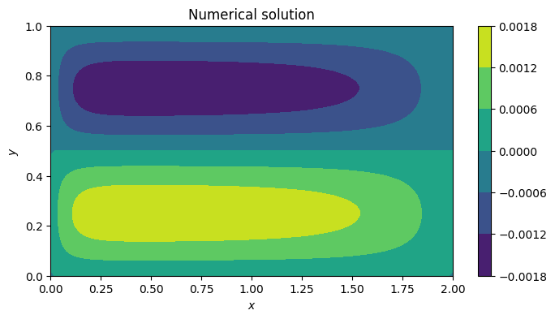

```python
fig, ax = plt.subplots(figsize=(8,4))

cmf = ax.contourf(X, Y, psi_out, 5)

ax.set_xlabel(r'$x$')
ax.set_ylabel(r'$y$')
ax.set_title('Numerical solution')
fig.colorbar(cmf)
```

```python
# small beta
Lx = 1.0
Ly = 1.0
nx = 51
r = 0.2
a = 1
beta = 0.0001
psi_out, X, Y = solve_stommel_fdm(Lx=Lx, Ly=Ly, nx=nx, r=r, a=a, beta=beta)
```

```
Convergence reached after 4653 iteration; L2 error 9.995052935326798e-11
```

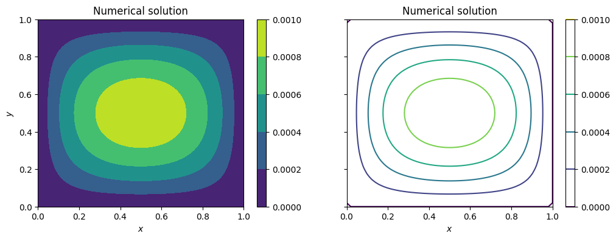

```python
fig, ax = plt.subplots(1,2, sharey=True, figsize=(12,4))

cmf = ax[0].contourf(X, Y, psi_out, 5)
cm = ax[1].contour(X, Y, psi_out, 5)

ax[0].set_xlabel(r'$x$')
ax[0].set_ylabel(r'$y$')
ax[0].set_title('Numerical solution')
fig.colorbar(cmf)

ax[1].set_xlabel(r'$x$')
ax[1].set_title('Numerical solution')
fig.colorbar(cm)
```

```python
# try real unit in 10^6 m
# note that if you use m: overfloat
Lx = 4
Ly = 4
nx = 51
r = 2e-6   # 10^-6 at limit
a = 1
beta = 2*2*np.pi / (3600*24*6400*1000) *1e6   # = around 2e-5 1/(10^6m s)
tau0 = 1e-10 # 10^2 Pa ?
psi_out, X, Y = solve_stommel_fdm(Lx=Lx, Ly=Ly, nx=nx, r=r, a=a, beta=beta, tau0=tau0)
```

```
Convergence reached after 320 iteration; L2 error 9.717634680413496e-11
```

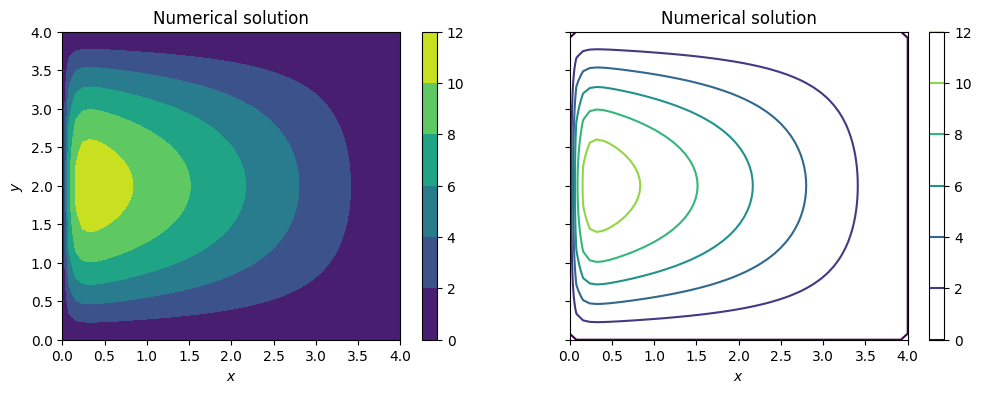

```python
fig, ax = plt.subplots(1,2, sharey=True, figsize=(12,4))

# z is in m, x,y in 10^6 m
# so psi is in 10^12 m^3/s, units of volume flux
# to scale it up by 1e6 -> psi is in Sv unit
factor = 1e6
psi_out = psi_out*factor

cmf = ax[0].contourf(X, Y, psi_out, 5)
cm = ax[1].contour(X, Y, psi_out, 5)

ax[0].set_xlabel(r'$x$')
ax[0].set_ylabel(r'$y$')
ax[0].set_title('Numerical solution')
fig.colorbar(cmf)

ax[1].set_xlabel(r'$x$')
ax[1].set_title('Numerical solution')
fig.colorbar(cm)
```